# Introduction

This notebook is only for exploring transaction data

### Daily transactions would be important to define an engagement metric

Found from an article that PayPal tracks below metrics to measure business performance:

1. Conversion Rate (%of successful transactions)
2. Total payment volume
3. Total transactions
4. Average transaction amount
5. Unique Users
6. Monthly active users
7. New user creation rate
8. Error rate
9. Decline rate
10. False positive rate (declined users who could have been good - based on test and control analysis)
11. Loss rate

> My aim would also be to check daily trends of these metrics (as many as possible) from provided transaction file.

# Analysis/Exploration

|  | transaction_id | transactions_type | transactions_currency | amount_usd | transactions_state | ea_cardholderpresence | ea_merchant_mcc | ea_merchant_city | ea_merchant_country | direction | user_id | created_date |
| --- | --- | --- | --- | --- | --- | --- | --- | --- | --- | --- | --- | --- |
| count | 2740075 | 2740075 | 2740075 | 2.740075e+06 | 2740075 | 1569481 | 1.581417e+06 | 1581281 | 1581096 | 2740075 | 2740075 | 2740075 |
| unique | 2740075 | 10 | 35 | NaN | 6 | 3 | NaN | 63253 | 198 | 2 | 18766 | 2739658 |
| top | transaction_1053809 | CARD_PAYMENT | EUR | NaN | COMPLETED | FALSE | NaN | London | GBR | OUTBOUND | user_12657 | 2018-12-04 12:13:34.572326 |
| freq | 1 | 1475780 | 1160135 | NaN | 2407968 | 1275460 | NaN | 92745 | 455924 | 2209795 | 5285 | 4 |
| mean | NaN | NaN | NaN | 1.703225e+05 | NaN | NaN | 5.699736e+03 | NaN | NaN | NaN | NaN | NaN |
| std | NaN | NaN | NaN | 9.634014e+07 | NaN | NaN | 9.493660e+02 | NaN | NaN | NaN | NaN | NaN |
| min | NaN | NaN | NaN | 0.000000e+00 | NaN | NaN | 7.420000e+02 | NaN | NaN | NaN | NaN | NaN |
| 25% | NaN | NaN | NaN | 2.030000e+00 | NaN | NaN | 5.411000e+03 | NaN | NaN | NaN | NaN | NaN |
| 50% | NaN | NaN | NaN | 8.510000e+00 | NaN | NaN | 5.812000e+03 | NaN | NaN | NaN | NaN | NaN |
| 75% | NaN | NaN | NaN | 2.822000e+01 | NaN | NaN | 5.921000e+03 | NaN | NaN | NaN | NaN | NaN |
| max | NaN | NaN | NaN | 8.510645e+10 | NaN | NaN | 9.406000e+03 | NaN | NaN | NaN | NaN | NaN |

```
<class 'pandas.core.frame.DataFrame'>
RangeIndex: 2740075 entries, 0 to 2740074
Data columns (total 12 columns):
transaction_id           object
transactions_type        object
transactions_currency    object
amount_usd               float64
transactions_state       object
ea_cardholderpresence    object
ea_merchant_mcc          float64
ea_merchant_city         object
ea_merchant_country      object
direction                object
user_id                  object
created_date             object
dtypes: float64(2), object(10)
memory usage: 250.9+ MB
```

### Transactions Profile Report

Overview

Dataset info

| Number of variables | 12 |
| --- | --- |
| Number of observations | 2740075 |
| Total Missing (%) | 14.1% |
| Total size in memory | 250.9 MiB |
| Average record size in memory | 96.0 B |

Variables types

| Numeric | 2 |
| --- | --- |
| Categorical | 9 |
| Boolean | 0 |
| Date | 0 |
| Text (Unique) | 1 |
| Rejected | 0 |
| Unsupported | 0 |

Warnings

- `amount_usd` is highly skewed (γ1 = 756.51) Skewed

- `amount_usd` has 58604 / 2.1% zeros Zeros

- `ea_cardholderpresence` has 1170594 / 42.7% missing values Missing

- `ea_merchant_mcc` has 1158658 / 42.3% missing values Missing

- `ea_merchant_city` has 1158794 / 42.3% missing values Missing

- `ea_merchant_city` has a high cardinality: 63254 distinct values Warning

- `ea_merchant_country` has 1158979 / 42.3% missing values Missing

- `ea_merchant_country` has a high cardinality: 199 distinct values Warning

- `user_id` has a high cardinality: 18766 distinct values Warning

- `created_date` has a high cardinality: 2739658 distinct values Warning

Variables

transaction_id  
Categorical, Unique

| First 3 values |
| --- |
| transaction_1053809 |
| transaction_298136 |
| transaction_1903313 |

| Last 3 values |
| --- |
| transaction_1042535 |
| transaction_446312 |
| transaction_672024 |

Toggle details

First 10 values

| Value | Count | Frequency (%) |  |
| --- | --- | --- | --- |
| transaction_0 | 1 | 0.0% |  |
| transaction_1 | 1 | 0.0% |  |
| transaction_10 | 1 | 0.0% |  |
| transaction_100 | 1 | 0.0% |  |
| transaction_1000 | 1 | 0.0% |  |

Last 10 values

| Value | Count | Frequency (%) |  |
| --- | --- | --- | --- |
| transaction_999995 | 1 | 0.0% |  |
| transaction_999996 | 1 | 0.0% |  |
| transaction_999997 | 1 | 0.0% |  |
| transaction_999998 | 1 | 0.0% |  |
| transaction_999999 | 1 | 0.0% |  |

transactions_type  
Categorical

| Distinct count | 10 |
| --- | --- |
| Unique (%) | 0.0% |
| Missing (%) | 0.0% |
| Missing (n) | 0 |

| CARD_PAYMENT | 1475780 |
| --- | --- |
| TRANSFER | 500409 |
| TOPUP | 388331 |
| Other values (7) | 375555 |

Toggle details

| Value | Count | Frequency (%) |  |
| --- | --- | --- | --- |
| CARD_PAYMENT | 1475780 | 53.9% |  |
| TRANSFER | 500409 | 18.3% |  |
| TOPUP | 388331 | 14.2% |  |
| EXCHANGE | 159148 | 5.8% |  |
| ATM | 93675 | 3.4% |  |
| CASHBACK | 82789 | 3.0% |  |
| FEE | 23659 | 0.9% |  |
| CARD_REFUND | 11962 | 0.4% |  |
| TAX | 2829 | 0.1% |  |
| REFUND | 1493 | 0.1% |  |

transactions_currency  
Categorical

| Distinct count | 35 |
| --- | --- |
| Unique (%) | 0.0% |
| Missing (%) | 0.0% |
| Missing (n) | 0 |

| EUR | 1160135 |
| --- | --- |
| GBP | 887795 |
| PLN | 231583 |
| Other values (32) | 460562 |

Toggle details

| Value | Count | Frequency (%) |  |
| --- | --- | --- | --- |
| EUR | 1160135 | 42.3% |  |
| GBP | 887795 | 32.4% |  |
| PLN | 231583 | 8.5% |  |
| RON | 167806 | 6.1% |  |
| USD | 80639 | 2.9% |  |
| CZK | 44970 | 1.6% |  |
| CHF | 39716 | 1.4% |  |
| SEK | 26804 | 1.0% |  |
| AUD | 16871 | 0.6% |  |
| NOK | 14271 | 0.5% |  |
| Other values (25) | 69485 | 2.5% |  |

amount_usd  
Numeric

| Distinct count | 48548 |
| --- | --- |
| Unique (%) | 1.8% |
| Missing (%) | 0.0% |
| Missing (n) | 0 |
| Infinite (%) | 0.0% |
| Infinite (n) | 0 |

| Mean | 170320 |
| --- | --- |
| Minimum | 0 |
| Maximum | 85106000000 |
| Zeros (%) | 2.1% |

Toggle details

**Statistics**

Quantile statistics

| Minimum | 0 |
| --- | --- |
| 5-th percentile | 0.05 |
| Q1 | 2.03 |
| Median | 8.51 |
| Q3 | 28.22 |
| 95-th percentile | 200 |
| Maximum | 85106000000 |
| Range | 85106000000 |
| Interquartile range | 26.19 |

Descriptive statistics

| Standard deviation | 96340000 |
| --- | --- |
| Coef of variation | 565.63 |
| Kurtosis | 614140 |
| Mean | 170320 |
| MAD | 340490 |
| Skewness | 756.51 |
| Sum | 466700000000 |
| Variance | 9281400000000000 |
| Memory size | 20.9 MiB |

**Histogram**

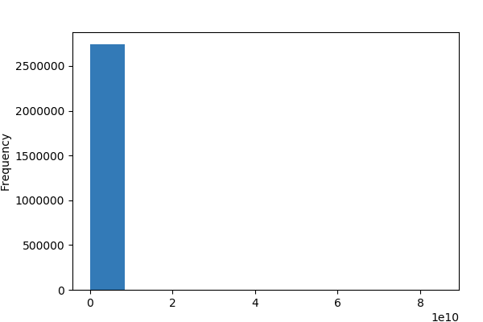

**Common Values**

| Value | Count | Frequency (%) |  |
| --- | --- | --- | --- |
| 0.0 | 58604 | 2.1% |  |
| 0.85 | 48062 | 1.8% |  |
| 0.01 | 46942 | 1.7% |  |
| 8.51 | 45169 | 1.6% |  |
| 10.0 | 37045 | 1.4% |  |
| 1.0 | 36276 | 1.3% |  |
| 17.02 | 32017 | 1.2% |  |
| 85.11 | 28881 | 1.1% |  |
| 42.55 | 28784 | 1.1% |  |
| 100.0 | 22588 | 0.8% |  |
| Other values (48538) | 2355707 | 86.0% |  |

**Extreme Values**

Minimum 5 values

| Value | Count | Frequency (%) |  |
| --- | --- | --- | --- |
| 0.0 | 58604 | 2.1% |  |
| 0.01 | 46942 | 1.7% |  |
| 0.02 | 14093 | 0.5% |  |
| 0.03 | 10026 | 0.4% |  |
| 0.04 | 6136 | 0.2% |  |

Maximum 5 values

| Value | Count | Frequency (%) |  |
| --- | --- | --- | --- |
| 25531935957.26 | 1 | 0.0% |  |
| 36000000000.0 | 1 | 0.0% |  |
| 51063871914.53 | 1 | 0.0% |  |
| 74641551593.26 | 1 | 0.0% |  |
| 85106453190.03 | 2 | 0.0% |  |

transactions_state  
Categorical

| Distinct count | 6 |
| --- | --- |
| Unique (%) | 0.0% |
| Missing (%) | 0.0% |
| Missing (n) | 0 |

| COMPLETED | 2407968 |
| --- | --- |
| DECLINED | 155286 |
| REVERTED | 112618 |
| Other values (3) | 64203 |

Toggle details

| Value | Count | Frequency (%) |  |
| --- | --- | --- | --- |
| COMPLETED | 2407968 | 87.9% |  |
| DECLINED | 155286 | 5.7% |  |
| REVERTED | 112618 | 4.1% |  |
| FAILED | 41053 | 1.5% |  |
| PENDING | 21492 | 0.8% |  |
| CANCELLED | 1658 | 0.1% |  |

ea_cardholderpresence  
Categorical

| Distinct count | 4 |
| --- | --- |
| Unique (%) | 0.0% |
| Missing (%) | 42.7% |
| Missing (n) | 1170594 |

| FALSE | 1275460 |
| --- | --- |
| TRUE | 288489 |
| UNKNOWN | 5532 |
| (Missing) | 1170594 |

Toggle details

| Value | Count | Frequency (%) |  |
| --- | --- | --- | --- |
| FALSE | 1275460 | 46.5% |  |
| TRUE | 288489 | 10.5% |  |
| UNKNOWN | 5532 | 0.2% |  |
| (Missing) | 1170594 | 42.7% |  |

ea_merchant_mcc  
Numeric

| Distinct count | 665 |
| --- | --- |
| Unique (%) | 0.0% |
| Missing (%) | 42.3% |
| Missing (n) | 1158658 |
| Infinite (%) | 0.0% |
| Infinite (n) | 0 |

| Mean | 5699.7 |
| --- | --- |
| Minimum | 742 |
| Maximum | 9406 |
| Zeros (%) | 0.0% |

Toggle details

**Statistics**

Quantile statistics

| Minimum | 742 |
| --- | --- |
| 5-th percentile | 4112 |
| Q1 | 5411 |
| Median | 5812 |
| Q3 | 5921 |
| 95-th percentile | 7832 |
| Maximum | 9406 |
| Range | 8664 |
| Interquartile range | 510 |

Descriptive statistics

| Standard deviation | 949.37 |
| --- | --- |
| Coef of variation | 0.16656 |
| Kurtosis | 3.3436 |
| Mean | 5699.7 |
| MAD | 591.28 |
| Skewness | 0.4816 |
| Sum | 9013700000 |
| Variance | 901300 |
| Memory size | 20.9 MiB |

**Histogram**

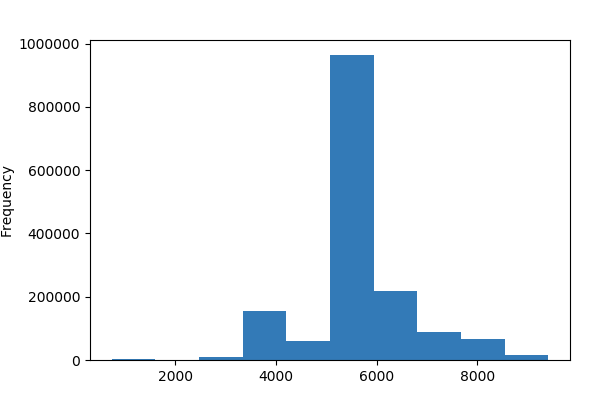

**Common Values**

| Value | Count | Frequency (%) |  |
| --- | --- | --- | --- |
| 5812.0 | 230209 | 8.4% |  |
| 5411.0 | 225700 | 8.2% |  |
| 5814.0 | 98509 | 3.6% |  |
| 6011.0 | 93783 | 3.4% |  |
| 4121.0 | 66692 | 2.4% |  |
| 5499.0 | 61908 | 2.3% |  |
| 4111.0 | 56866 | 2.1% |  |
| 5813.0 | 53702 | 2.0% |  |
| 5541.0 | 42892 | 1.6% |  |
| 7011.0 | 34281 | 1.3% |  |
| Other values (654) | 616875 | 22.5% |  |
| (Missing) | 1158658 | 42.3% |  |

**Extreme Values**

Minimum 5 values

| Value | Count | Frequency (%) |  |
| --- | --- | --- | --- |
| 742.0 | 587 | 0.0% |  |
| 763.0 | 1068 | 0.0% |  |
| 780.0 | 37 | 0.0% |  |
| 1338.0 | 10 | 0.0% |  |
| 1339.0 | 15 | 0.0% |  |

Maximum 5 values

| Value | Count | Frequency (%) |  |
| --- | --- | --- | --- |
| 9311.0 | 601 | 0.0% |  |
| 9399.0 | 4597 | 0.2% |  |
| 9402.0 | 2158 | 0.1% |  |
| 9405.0 | 790 | 0.0% |  |
| 9406.0 | 56 | 0.0% |  |

ea_merchant_city  
Categorical

| Distinct count | 63254 |
| --- | --- |
| Unique (%) | 2.3% |
| Missing (%) | 42.3% |
| Missing (n) | 1158794 |

| London | 92745 |
| --- | --- |
| Bucuresti | 33227 |
| Vilnius | 30379 |
| Other values (63250) | 1424930 |
| (Missing) | 1158794 |

Toggle details

| Value | Count | Frequency (%) |  |
| --- | --- | --- | --- |
| London | 92745 | 3.4% |  |
| Bucuresti | 33227 | 1.2% |  |
| Vilnius | 30379 | 1.1% |  |
| Dublin | 25246 | 0.9% |  |
| 35314369001 | 23157 | 0.8% |  |
| help.uber.com | 21133 | 0.8% |  |
| Warszawa | 20232 | 0.7% |  |
| tfl.gov.uk/cp | 18271 | 0.7% |  |
| Paris | 16758 | 0.6% |  |
| Amsterdam | 16025 | 0.6% |  |
| Other values (63243) | 1284108 | 46.9% |  |
| (Missing) | 1158794 | 42.3% |  |

ea_merchant_country  
Categorical

| Distinct count | 199 |
| --- | --- |
| Unique (%) | 0.0% |
| Missing (%) | 42.3% |
| Missing (n) | 1158979 |

| GBR | 455924 |
| --- | --- |
| IRL | 122993 |
| USA | 100203 |
| Other values (195) | 901976 |
| (Missing) | 1158979 |

Toggle details

| Value | Count | Frequency (%) |  |
| --- | --- | --- | --- |
| GBR | 455924 | 16.6% |  |
| IRL | 122993 | 4.5% |  |
| USA | 100203 | 3.7% |  |
| FRA | 99637 | 3.6% |  |
| POL | 83431 | 3.0% |  |
| ESP | 64194 | 2.3% |  |
| NLD | 58563 | 2.1% |  |
| LTU | 43134 | 1.6% |  |
| ROM | 38630 | 1.4% |  |
| DEU | 30652 | 1.1% |  |
| Other values (188) | 483735 | 17.7% |  |
| (Missing) | 1158979 | 42.3% |  |

direction  
Categorical

| Distinct count | 2 |
| --- | --- |
| Unique (%) | 0.0% |
| Missing (%) | 0.0% |
| Missing (n) | 0 |

| OUTBOUND | 2209795 |
| --- | --- |
| INBOUND | 530280 |

Toggle details

| Value | Count | Frequency (%) |  |
| --- | --- | --- | --- |
| OUTBOUND | 2209795 | 80.6% |  |
| INBOUND | 530280 | 19.4% |  |

user_id  
Categorical

| Distinct count | 18766 |
| --- | --- |
| Unique (%) | 0.7% |
| Missing (%) | 0.0% |
| Missing (n) | 0 |

| user_12657 | 5285 |
| --- | --- |
| user_4243 | 3381 |
| user_10794 | 3223 |
| Other values (18763) | 2728186 |

Toggle details

| Value | Count | Frequency (%) |  |
| --- | --- | --- | --- |
| user_12657 | 5285 | 0.2% |  |
| user_4243 | 3381 | 0.1% |  |
| user_10794 | 3223 | 0.1% |  |
| user_1285 | 3056 | 0.1% |  |
| user_10869 | 2913 | 0.1% |  |
| user_15946 | 2894 | 0.1% |  |
| user_189 | 2762 | 0.1% |  |
| user_5896 | 2755 | 0.1% |  |
| user_4648 | 2749 | 0.1% |  |
| user_120 | 2687 | 0.1% |  |
| Other values (18756) | 2708370 | 98.8% |  |

created_date  
Categorical

| Distinct count | 2739658 |
| --- | --- |
| Unique (%) | 100.0% |
| Missing (%) | 0.0% |
| Missing (n) | 0 |

| 2018-12-04 12:13:34.572326 | 4 |
| --- | --- |
| 2018-12-22 07:24:30.960017 | 3 |
| 2018-12-13 14:49:24.314528 | 3 |
| Other values (2739655) | 2740065 |

Toggle details

| Value | Count | Frequency (%) |  |
| --- | --- | --- | --- |
| 2018-12-04 12:13:34.572326 | 4 | 0.0% |  |
| 2018-12-22 07:24:30.960017 | 3 | 0.0% |  |
| 2018-12-13 14:49:24.314528 | 3 | 0.0% |  |
| 2018-10-25 10:06:43.624650 | 3 | 0.0% |  |
| 2019-05-09 08:48:56.864973 | 3 | 0.0% |  |
| 2019-04-10 16:18:50.415533 | 2 | 0.0% |  |
| 2018-12-24 04:30:52.145689 | 2 | 0.0% |  |
| 2018-10-11 12:04:50.171157 | 2 | 0.0% |  |
| 2018-10-12 11:31:36.820010 | 2 | 0.0% |  |
| 2019-03-23 17:37:12.552557 | 2 | 0.0% |  |
| Other values (2739648) | 2740049 | 100.0% |  |

Correlations

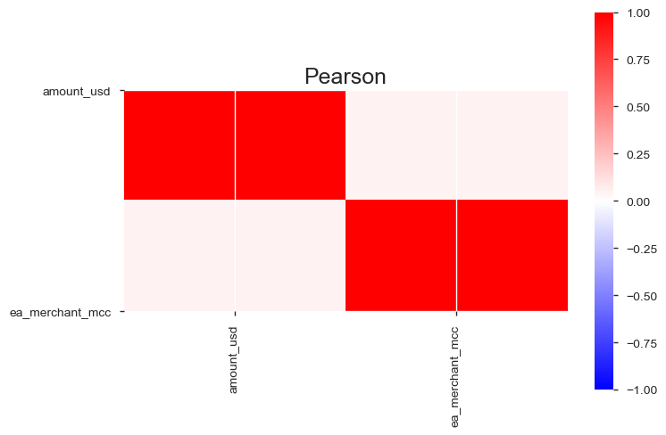

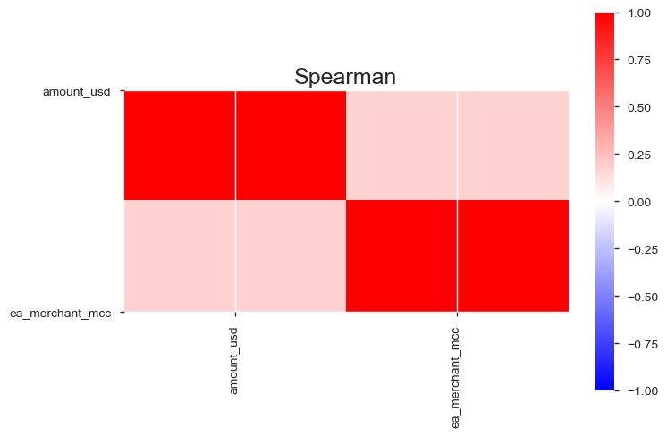

Sample

|  | transaction_id | transactions_type | transactions_currency | amount_usd | transactions_state | ea_cardholderpresence | ea_merchant_mcc | ea_merchant_city | ea_merchant_country | direction | user_id | created_date |
| --- | --- | --- | --- | --- | --- | --- | --- | --- | --- | --- | --- | --- |
| 0 | transaction_0 | TRANSFER | AED | 4.55 | COMPLETED | NaN | NaN | NaN | NaN | OUTBOUND | user_898 | 2018-04-03 03:34:21.784487 |
| 1 | transaction_1 | CARD_PAYMENT | AED | 15.50 | COMPLETED | FALSE | 4111.0 | Dubai | ARE | OUTBOUND | user_1652 | 2019-03-19 06:15:59.537032 |
| 2 | transaction_2 | CARD_PAYMENT | AED | 43.40 | COMPLETED | FALSE | 5814.0 | Dubai | ARE | OUTBOUND | user_1652 | 2019-03-18 18:53:41.323032 |
| 3 | transaction_3 | TRANSFER | AED | 10043.01 | COMPLETED | NaN | NaN | NaN | NaN | OUTBOUND | user_1652 | 2019-03-22 14:20:01.513032 |
| 4 | transaction_4 | CARD_PAYMENT | AED | 43.81 | COMPLETED | FALSE | 5651.0 | Abu Dhabi | ARE | OUTBOUND | user_5509 | 2019-03-22 05:42:50.316652 |

Profile report shows that ea_cardholderpresence, ea_merchant_mcc, ea_merchant_city and ea_merchant_country have over 40% missing data. It makes sense to drop them for now, will add later if the need comes.

> Transaction_Type distribution suggests that CARD_PAYMENTs and TRANSFERs are the most frequent uses.

> EUR & GBP are most frequently transacted currencies

> amount_usd has unusually high values which is making it highly skewed, need to check the distribution of it across transaction_state

> time can be extracted from created_dt and changed into a bucket of MORNING, NOON, AFTERNOON, EVENING, NIGHT & LATE-NIGHT

> Also, overall conversion rate (transaction_state : COMPLETED) is ~88%, error rate (transaction_state : REVERTED/FAILED) and declined rate (transaction_state : DECLINED) is ~6%

### Treating DateTime variable

```
0   2018-04-03 03:34:21.784487
1   2019-03-19 06:15:59.537032
2   2019-03-18 18:53:41.323032
3   2019-03-22 14:20:01.513032
4   2019-03-22 05:42:50.316652
5   2019-03-25 04:08:49.772652
6   2019-03-17 17:57:06.816032
7   2019-03-17 21:22:28.723032
8   2019-03-16 12:17:42.586032
9   2019-03-17 14:42:36.520032
Name: created_date, dtype: datetime64[ns]
```

```
0    LateNight
1      Morning
2      Evening
3    Afternoon
4    LateNight
5    LateNight
6      Evening
7        Night
8         Noon
9    Afternoon
Name: TimeofDay, dtype: object
LateNight    0.213116
Night        0.194474
Morning      0.183722
Evening      0.153924
Noon         0.132401
Afternoon    0.122363
Name: TimeofDay, dtype: float64
```

> Over 20% of transactions have happened pretty late in night (probably late night after-parties :D)

## Analysis on VOLUME

### Trend of count

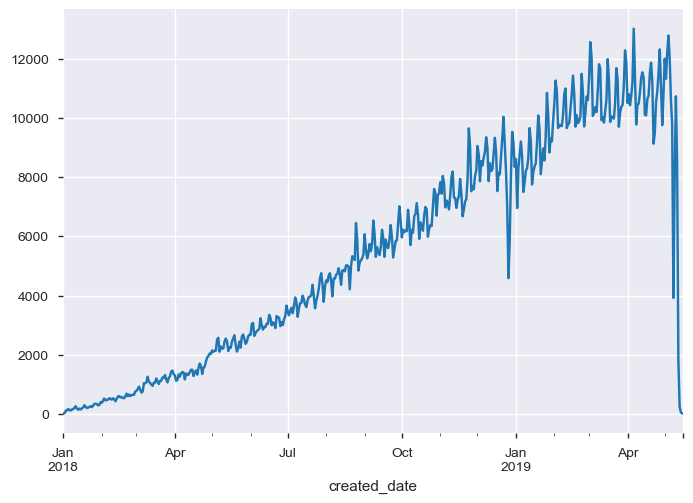

Sharp drop in May19 - probably data is not complete

> Assumption-1 : Data is not correct after April19 and safe to ignore.

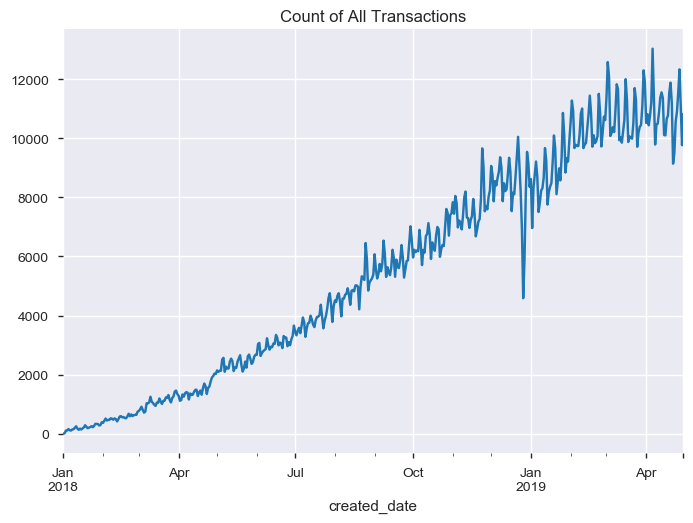

Number of transactions are constantly increasing which is a good sign. There is also a sharp drop in Dec18 which is likely because most people stay at home during Christmas holiday periods and eventually spend less.

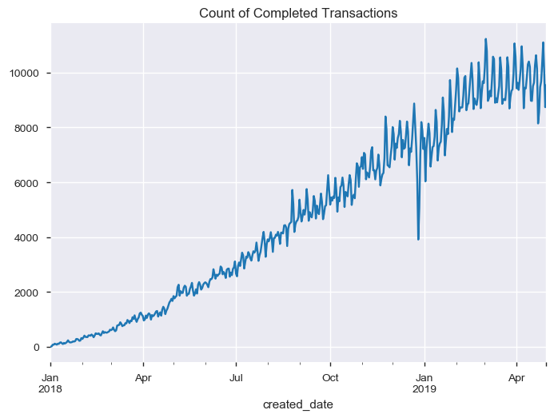

COMPLETED transactions and ALL transactions have exactly similar trends which suggests it is most common transaction type (obviously)

### Trend of rate

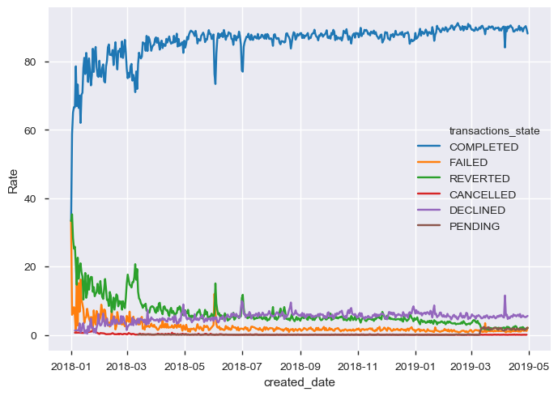

> It's clear that FAILED and REVERTED transactions were pretty high in first quarter of 2018, draggin COMPLETED transactions down. Eventually over the course of the time, all transactions have stabilized which is a good sign for the business.

> DECLINED transactions have been very stable throughout, good to see that upsurge of customers have not caused havoc in the system.

> There is a sudden increase in PENDING transactions after Mar19, this needs to be investigated further.

## Analysis on AMOUNT

### Trend of All Amounts

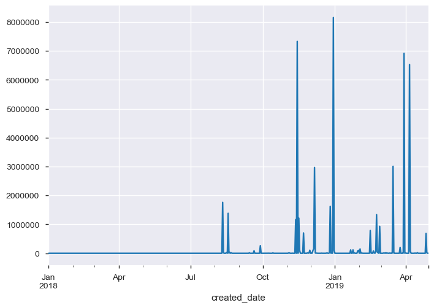

There are some unusually high transactions. Profile report shows that 95% of amount_usd values are below 200.

Creating a new column with capped amount and also a flag to keep track of users attempting unusual transactions.

> Assumption-2 : Large transaction amounts are sign of potential frauds

### Trend of Capped Amounts

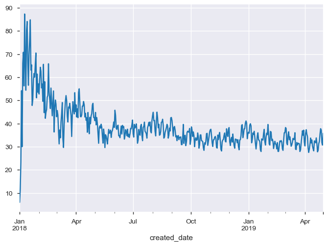

### Trend across Trasaction States

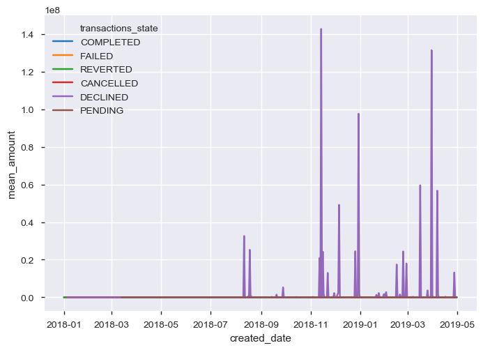

In all this mess, COMPLETED transactions have completely suppressed and have absolutely no visibility. Since COMPLETED transactions would be the one generating true customer experience for the product, it makes sense to only keep focus on COMPLETED transactions and drop all other transaction states to remove noise from data.

> Assumption-3 : Only COMPLETED transactions are going to develop true customer engagement

### Trend of Only Completed Transactions

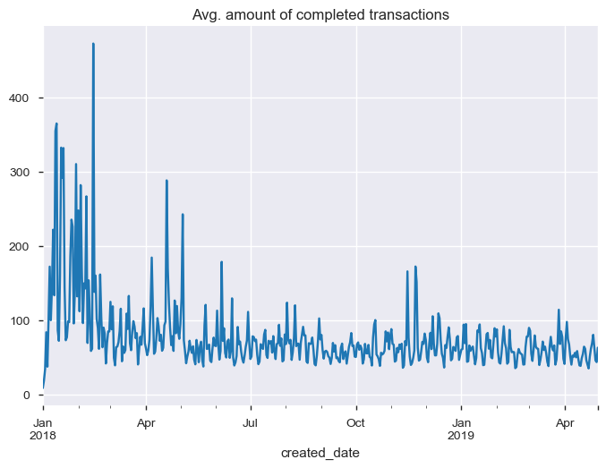

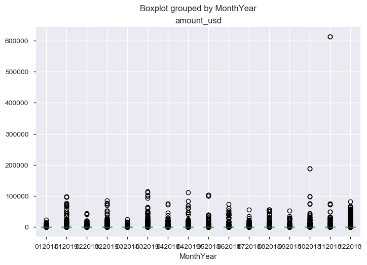

There are still many high ticket transactions every month which are skewing the distribution big time.

Let's check distribution of log-transformed value of amount column.

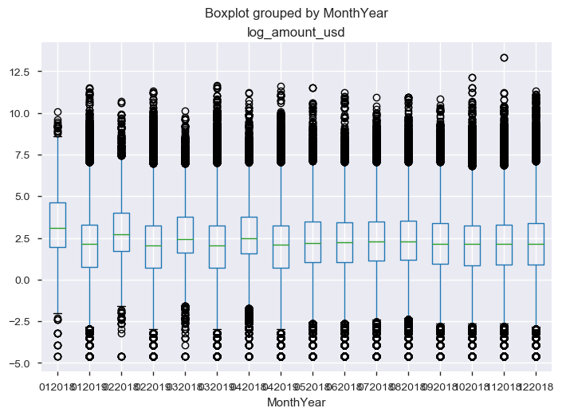

It's clear that distribution of amount column acorss months is pretty stable, and even outliers are pretty much same each month.

Few high ticket transactions each month is good for business, though I am slight concerned about no steady increase in median value over months (expected since the volume is steadily increasing). This infers that all new customers have very similar spending/usage behaviour.

> Assumption-4: All customer (new & old) have similar spending behaviour since there is no increase in median value of amount across months

### Trend across Transaction Types

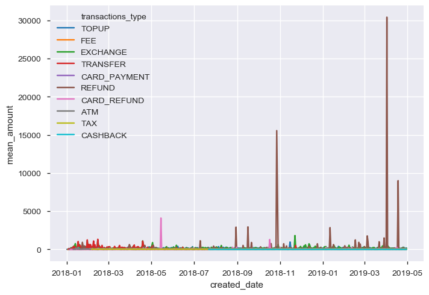

There are very unusual REFUND/CARD_REFUND values, it will be interesting to check the distribution without these transactions.

### Trend without REFUNDS

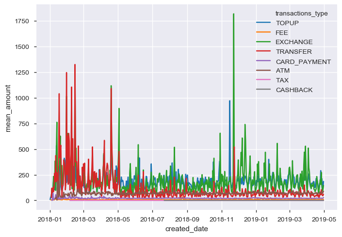

- FEE, TAX & CASHBACK amounts are low which makes sense since they would largely depend on other transactions and would be equally applicable to all users
- ATM usage is also low and very steady across months which suggests withdrawals are not major usage of card (my kind of people ;))

### Trend without REFUNDS, FEE, TAX & CASHBACK

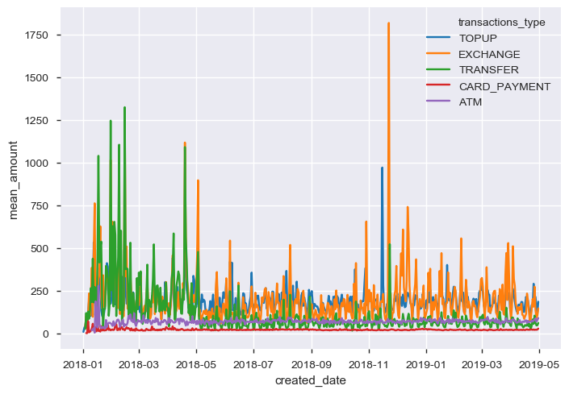

> Assumption-5: REFUND, CARD_REFUND, FEE, TAX & CASHBACK transaction types are not useful for defining an engagement of a user

It seems CARD_PAYMENT and ATM usage are stable over the time whereas TOPUP, EXCHANGE and TRANSFER are the transction types producing real thrust for the business.

|  | transaction_id | transactions_type | transactions_currency | amount_usd | transactions_state | direction | user_id | created_date | TimeofDay | PotentialFraud | amount_usd_capped | MonthYear | log_amount_usd |
| --- | --- | --- | --- | --- | --- | --- | --- | --- | --- | --- | --- | --- | --- |
| 0 | transaction_0 | TRANSFER | AED | 4.55 | COMPLETED | OUTBOUND | user_898 | 2018-04-03 | LateNight | 0 | 4.55 | 042018 | 1.515127 |
| 1 | transaction_1 | CARD_PAYMENT | AED | 15.50 | COMPLETED | OUTBOUND | user_1652 | 2019-03-19 | Morning | 0 | 15.50 | 032019 | 2.740840 |
| 2 | transaction_2 | CARD_PAYMENT | AED | 43.40 | COMPLETED | OUTBOUND | user_1652 | 2019-03-18 | Evening | 0 | 43.40 | 032019 | 3.770459 |
| 3 | transaction_3 | TRANSFER | AED | 10043.01 | COMPLETED | OUTBOUND | user_1652 | 2019-03-22 | Afternoon | 1 | 300.00 | 032019 | 9.214632 |
| 4 | transaction_4 | CARD_PAYMENT | AED | 43.81 | COMPLETED | OUTBOUND | user_5509 | 2019-03-22 | LateNight | 0 | 43.81 | 032019 | 3.779862 |

## Analysis on USERS

### Trend across Transaction States

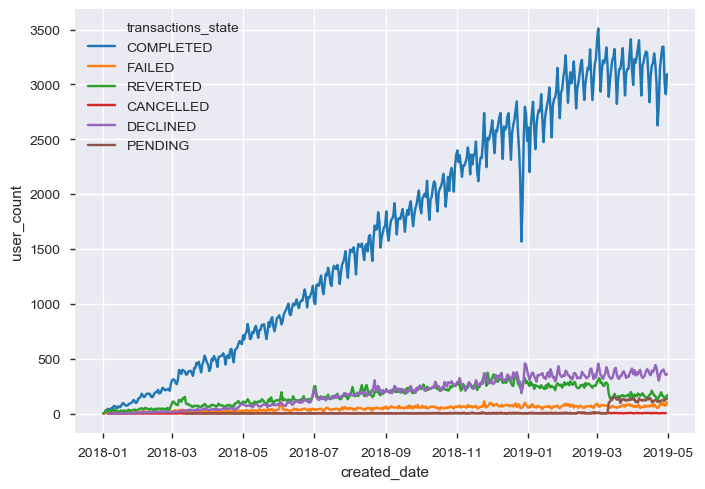

- Constant rise in number of users is a good sign
- Increase in the number of users with DECLINED transactions might be a challenge for business
- Number of users with REVERTED transactions has dropped towards end of April and May19 which is a good

### Trend across Transaction Types of COMPLETED Transactions

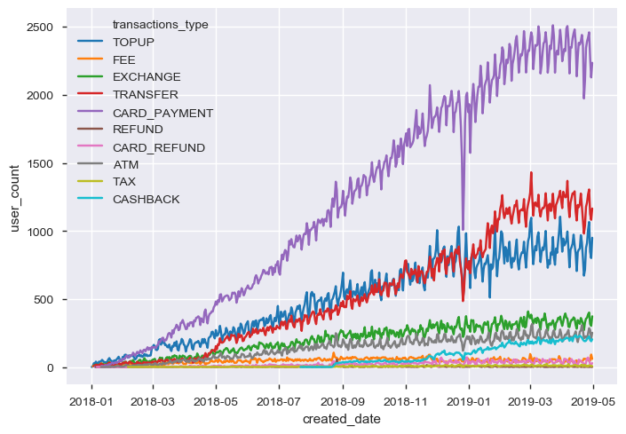

- Again, it's visible that CARD_PAYMENT, TRANSFER & TOPUP have covered most of the user base
- EXCHANGE, ATM and CASHBACK have started picking up towards the end
- All transction types have a dip in Christmas month

### Trend across FILTERED Transaction Types of COMPLETED Transactions

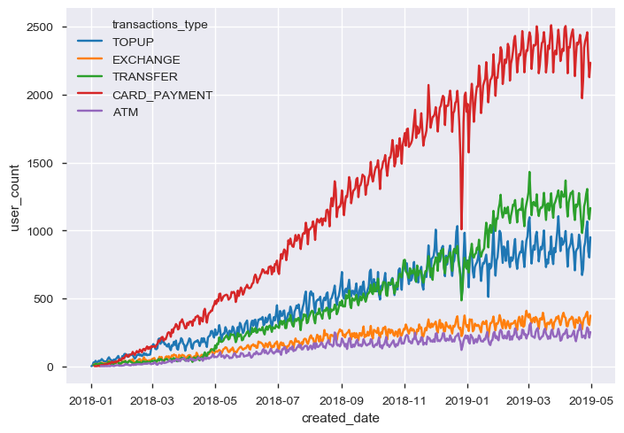

### Daily NEW users acquisition (across FILTERD transactions)

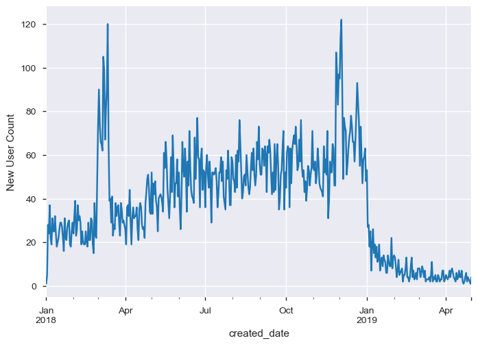

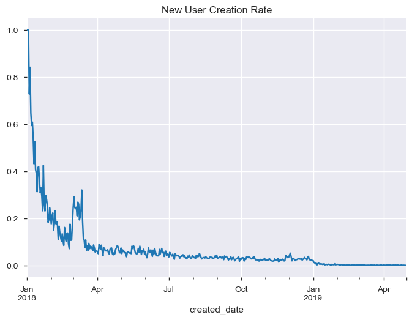

> Daily acquisition of NEW customers was averaging almost above 40 in 2018 and dropped close below 10 in 2019

> New acquistion rate has also been dropping since the beginning

### Distribution of Average Days b/w Transactions

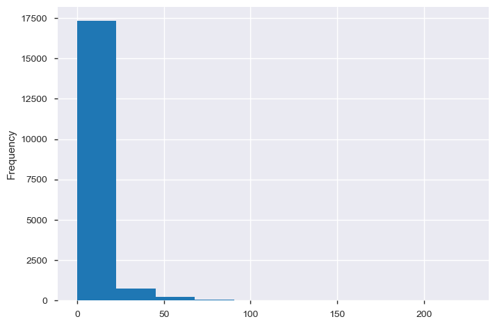

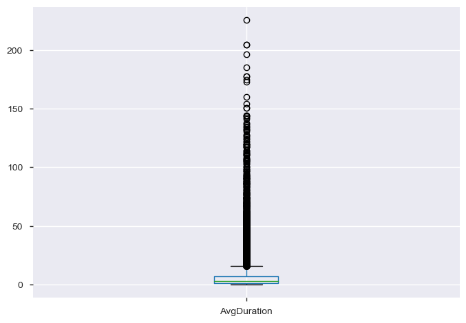

### Distribution b/w Avg. Duration and Avg. Amount

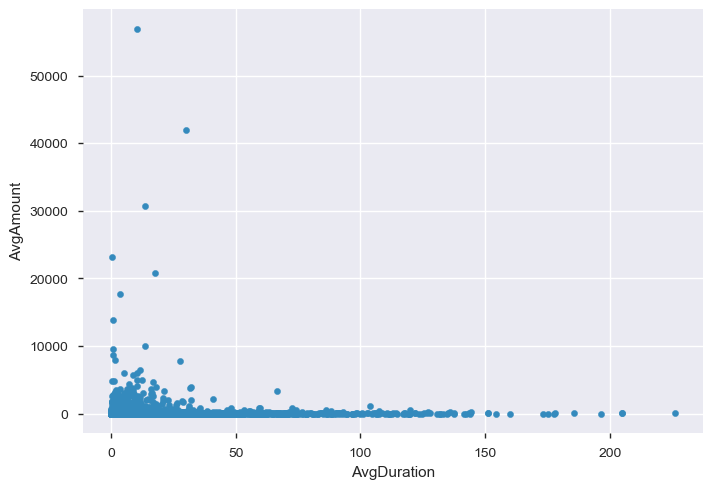

> Few users with unusual high average amount are skewing the results

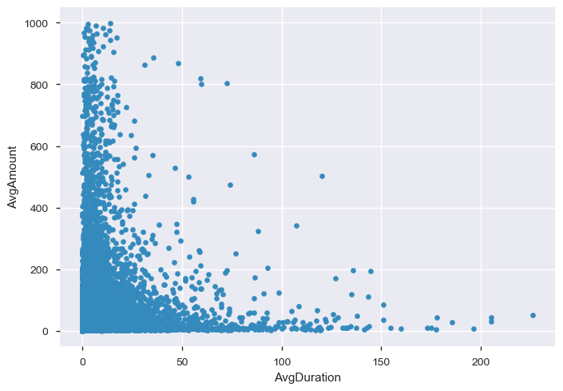

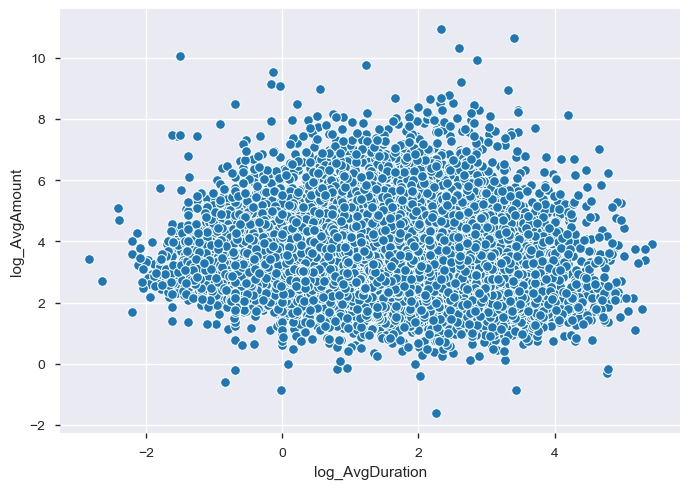

- It can be seen, that usage pattern is scattered in a big circle with a center somewhere around (2, 4)
- This can be easily divided in 4 quandrants by choosing thresholds for log_AvgAmount and log_AvgDuration
- K-means clustering can be used to capture those thresholds

# Clustering

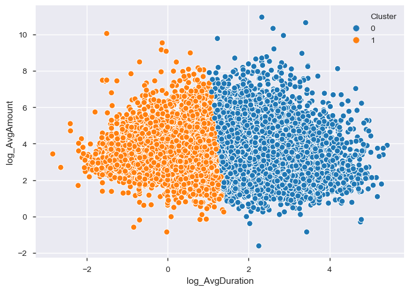

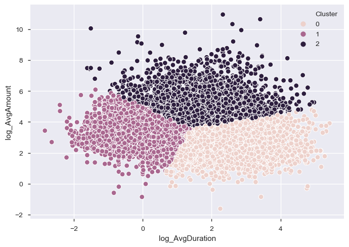

```
[[ 1.26698878  3.42156525]
 [ 1.68586054  5.18611761]
 [-0.2336551   3.40665254]
 [ 2.87395319  2.64032222]]
```

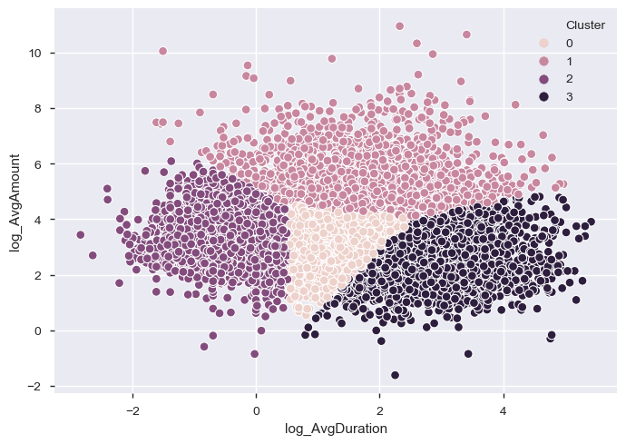

- Cluster 0 : these users have overall avgerage amount of spending within an average time duration which makes them engaged
- Cluster 1 : these users have relatively high average of spending amount with a mix of both low and high duration
- Cluster 2 : these users have low average of spending amount but their spend duration is also low which makes them enaged on the platform
- Cluster 3 : these users have long duration b/w their transactions which is definitely a sign of disengagement

> Clustering distribution is not as clean as expected, though it can be seen that cluster 0 & 2 users are more engaged with the product and cluster 3 is not (long gaps between their transactions)

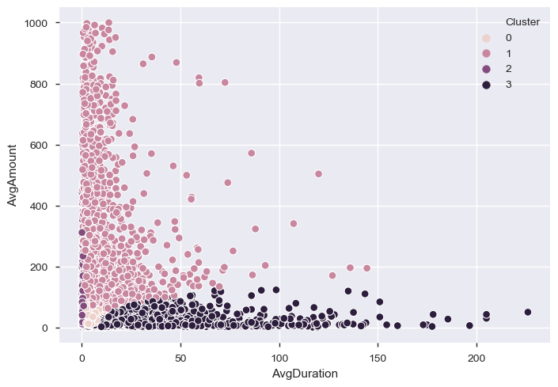

```
1    10524
0     6432
Name: Engaged, dtype: int64
```

# Summary

During this analysis following inferences and assumptions have been developed to set a definition for engaged user

**Assumption-1:** Data is not correct after April19 and safe to ignore.  
**Assumption-2:** Large transaction amounts are sign of potential frauds.  
**Assumption-3:** Only COMPLETED transactions are going to develop true customer engagement.  
**Assumption-4:** All customer (new & old) have similar spending behaviour since there is no increase in median value of amount across months.  
**Assumption-5:** REFUND, CARD_REFUND, FEE, TAX & CASHBACK transaction types are not useful for defining an engagement of a user.

Overall, constant increase in number of transactions and users is happy sign for the business whereas there are also few setbacks in terms of sharp drop in new customer acquisition rate and insignificant change in median value of spend amount in over 16 months.

**New user acquisition rate = (No. of users doing their first trasaction in a particular day)/(No. of users in that day)

This has been constantly declining and by the end of April19 has reached to its minimum value, which is particulary a worry sign for business.

**AvgDuration = (No. of days between first and last transaction)/Total No. of transactions

Note that this was calculated only for COMPLETED transactions.

AvgAmount of COMPLETED Transactions along with AvgDuration helped in seggregating engaged customers from unengaged one.

# Conclusion

> K-Means clustering approach between transformed dimensions of average amount of transaction and average duration between successive transactions for users has been taken to define engaged customers (cluster center is used to set thresholds)